# Linear Regression Assignment

Mendoza College of Business

02/09/2021

# Set Up

```r
library(ggplot2)
load("nba_data.rda") # Load data
```

The dataset we are using contains statistics on NBA games from 2010 to 2021, the features in the data are:

The statistics calculated are:

- fgm - Field goals made
- fga - Field goals attempted
- fg3m - 3 point shots made
- fg3a - 3 point shots attempted
- fg2m - 2 point shots made
- fg2a - 2 point shots attempted
- ftm - Free throws made
- fta - Free throws attempted
- oreb - Offensive rebounds
- dreb - Defensive rebounds
- treb - Total rebounds
- ast - Assists
- stl - Steals
- blk - Blocks
- tov - Turnovers
- pf - Personal fouls
- pts - Points scored
- pctfg - Field goal percentage
- pctfg2 - 2 point field goal percentage
- pctfg3 - 3 point field goal percentage
- pctft - Free throw percentage

These are calculated for the different aspects of the matchup denoted by the following adjustments to the variable names:

- _1_off - Offensive stats for team 1 in previous games
- _1_def - Defensive stats for team 1 in previous games (That is stats from team 1’s opponents)
- _2_off - Offensive stats for team 2 in previous games
- _2_def - Defensive stats for team 2 in previous games (That is stats from team 2’s opponents)

There is also an ELO rating function which can be used to provide a ranking of the teams:

https://medium.com/purple-theory/what-is-elo-rating-c4eb7a9061e0

The objective of our analysis is to determine the key factors involved in winning NBA games, so we will use point differential as our response variable.

```r
# Create response variable
nba_data$point_diff <- nba_data$team_1_points - nba_data$team_2_points
```

Before running the model we want to drop all of the unique identifiers for the games and the points used to calculate the differential:

```r
# Drop columns categorical
nba_model <- nba_data[,c(8:91, 94:96)]
```

# Assignment

Please complete the following tasks and answer the following questions:

- 1 - Create two visualizations which may reveal interesting relationships in the dataset. Describe what you see in the visualization. (2 Points)

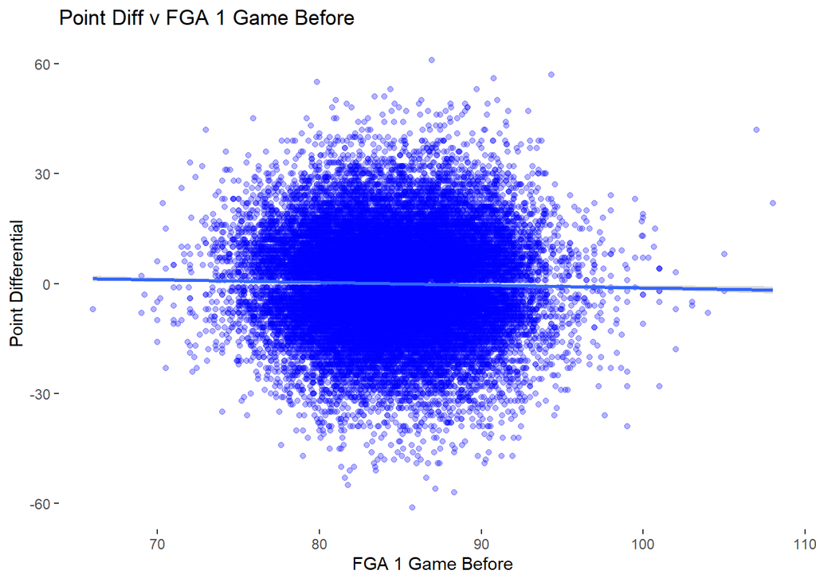

```r
g_1 <- ggplot(nba_model, # Set dataset
              aes(y = point_diff, # Set y-axis as insurance charges
                  x = fga_1_off)) + # Set x-axis as age.
  geom_point(color = "blue", alpha = 0.3) + # Use geom_point to get scatter plot
  geom_smooth(method = "lm") + # Add smoothing line
  theme_bw() + # Set theme for plot
  theme(panel.grid.major = element_blank(), # Turn of the background grid
        panel.grid.minor = element_blank(),
        panel.border = element_blank(),
        panel.background = element_blank()) +
  labs(y = "Point Differential", # Set plot labels
       x = "FGA 1 Game Before",
       title = "Point Diff v FGA 1 Game Before")

g_1 # Generate plot
```

There is seemingly no relationship between point differential and the field goals attempted 1 game before.

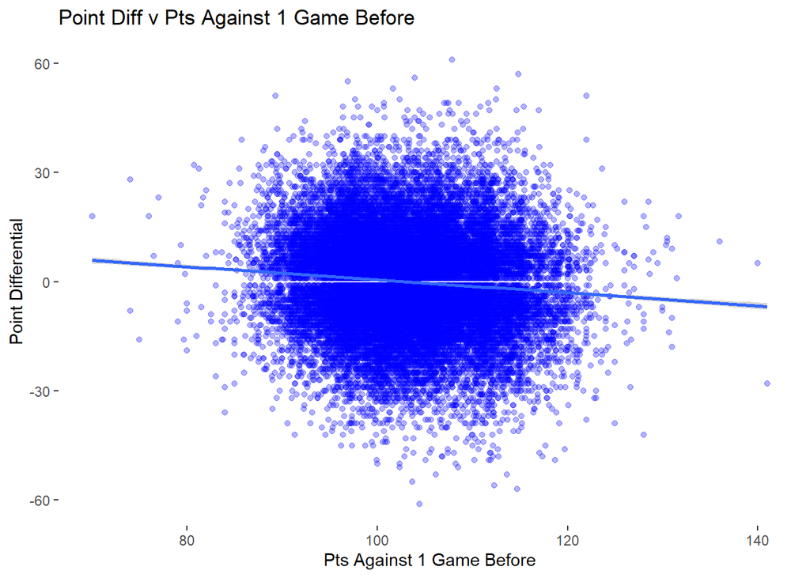

```r
g_2 <- ggplot(nba_model, # Set dataset
              aes(y = point_diff, # Set y-axis as insurance charges
                  x = pts_1_def)) + # Set x-axis as age.
  geom_point(color = "blue", alpha = 0.3) + # Use geom_point to get scatter plot
  geom_smooth(method = "lm") + # Add smoothing line
  theme_bw() + # Set theme for plot
  theme(panel.grid.major = element_blank(), # Turn of the background grid
        panel.grid.minor = element_blank(),
        panel.border = element_blank(),
        panel.background = element_blank()) +
  labs(y = "Point Differential", # Set plot labels
       x = "Pts Against 1 Game Before",
       title = "Point Diff v Pts Against 1 Game Before")

g_2 # Generate plot
```

There is a very weak negative relationship between points against in the game before and point diff.

- 2 - Run a linear regression model on the dataset using `point_diff` as the response variable and all other variables in the model data as explanatory variables. (1 Point)

```r
fit1 <- lm(point_diff ~ ., data = nba_model)
```

- 3 - What features in the model were significant (At 0.1% level)? Do these variables have a positive or negative effect on a teams change of winning a game? (1 Point)

```r
summary(fit1)
```

```
##
## Call:
## lm(formula = point_diff ~ ., data = nba_model)
##
## Residuals:
##     Min      1Q  Median      3Q     Max
## -57.249  -8.270  -0.001   8.290  57.911
##
## Coefficients: (16 not defined because of singularities)
##                Estimate Std. Error t value Pr(>|t|)
## (Intercept)  -1.683e+01  6.866e+01  -0.245 0.806317
## fgm_1_off     1.347e+00  8.183e-01   1.646 0.099747 .
## fga_1_off    -7.241e-01  3.838e-01  -1.887 0.059211 .
## fg3m_1_off   -5.723e-01  4.469e-01  -1.281 0.200335
## fg3a_1_off    4.471e-01  2.044e-01   2.187 0.028728 *
## fg2m_1_off           NA         NA      NA       NA
## fg2a_1_off           NA         NA      NA       NA
## ftm_1_off     3.031e-02  4.742e-01   0.064 0.949034
## fta_1_off    -1.374e-02  3.657e-01  -0.038 0.970027
## oreb_1_off    2.764e-01  8.899e-02   3.106 0.001901 **
## dreb_1_off    2.203e-01  6.430e-02   3.426 0.000614 ***
## treb_1_off           NA         NA      NA       NA
## ast_1_off     1.202e-01  4.380e-02   2.745 0.006058 **
## stl_1_off     3.867e-01  9.299e-02   4.158 3.22e-05 ***
## blk_1_off     1.854e-01  7.991e-02   2.320 0.020326 *
## tov_1_off    -3.675e-01  8.572e-02  -4.287 1.82e-05 ***
## pf_1_off      1.373e-01  6.597e-02   2.081 0.037457 *
## pts_1_off            NA         NA      NA       NA
## pctfg_1_off  -5.284e+01  6.495e+01  -0.814 0.415874
## pctfg2_1_off -2.064e+01  2.217e+01  -0.931 0.351977
## pctfg3_1_off  5.612e+00  7.233e+00   0.776 0.437773
## pctft_1_off   7.841e+00  1.130e+01   0.694 0.487711
## fgm_1_def    -2.781e+00  9.925e-01  -2.802 0.005079 **
## fga_1_def     1.301e+00  4.659e-01   2.793 0.005230 **
## fg3m_1_def    8.153e-01  6.714e-01   1.214 0.224605
## fg3a_1_def   -4.456e-01  3.046e-01  -1.463 0.143534
## fg2m_1_def           NA         NA      NA       NA
## fg2a_1_def           NA         NA      NA       NA
## ftm_1_def    -6.687e-01  6.736e-01  -0.993 0.320889
## fta_1_def     3.766e-01  5.150e-01   0.731 0.464626
```

[output cut: 49 more lines]

```
## pf_2_def     -1.319e-01  9.395e-02  -1.404 0.160252
## pts_2_def            NA         NA      NA       NA
## pctfg_2_def  -1.361e+02  7.679e+01  -1.773 0.076249 .
## pctfg2_2_def -3.649e+01  3.437e+01  -1.062 0.288339
## pctfg3_2_def -1.045e+01  1.070e+01  -0.977 0.328546
## pctft_2_def  -2.188e+01  1.611e+01  -1.359 0.174287
## elo_2        -2.418e-02  1.713e-03 -14.117  < 2e-16 ***
## elo_1         2.583e-02  1.649e-03  15.668  < 2e-16 ***
## ---
## Signif. codes:  0 '***' 0.001 '**' 0.01 '*' 0.05 '.' 0.1 ' ' 1
##
## Residual standard error: 12.77 on 27895 degrees of freedom
##   (430 observations deleted due to missingness)
## Multiple R-squared:  0.157,  Adjusted R-squared:  0.1549
## F-statistic: 74.21 on 70 and 27895 DF,  p-value: < 2.2e-16
```

```r
p_values <- summary(fit1)$coefficients[, "Pr(>|t|)"]
significant_terms <- summary(fit1)$coefficients[p_values < 0.001, ]
significant_terms
```

```
##               Estimate  Std. Error    t value     Pr(>|t|)
## dreb_1_off  0.22028731 0.064300385   3.425910 6.136269e-04
## stl_1_off   0.38666313 0.092987100   4.158245 3.216599e-05
## tov_1_off  -0.36748528 0.085725385  -4.286773 1.818953e-05
## ast_1_def  -0.24289473 0.064528272  -3.764160 1.674524e-04
## ast_2_def   0.22032136 0.064933714   3.393020 6.922276e-04
## elo_2      -0.02417700 0.001712581 -14.117289 4.250751e-45
## elo_1       0.02583314 0.001648813  15.667716 4.320497e-55
```

dreb_1_off, stl_1_off, ast_2_def and elo_1 have a postiive effect. tov_1_off, ast_1_de and elo_2 have a negative effect.

- 4 - Visualize two potential interaction terms and their relationship with the response variable. Are these interaction terms likely to have a significant relationship with the response variable? (2 Points)

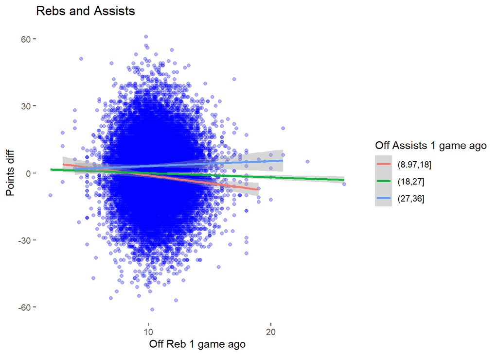

```r
# Create plot
g_2 <- ggplot(nba_model, # Set dataset
              aes(y = point_diff,
                  color = cut(ast_1_off,3), # Set y-axis
                  x = oreb_1_off)) + # Set x-axis
  geom_point(color = "blue", alpha = 0.3) + # Use geom_point to get scatter plot
  geom_smooth(method = "lm") + # Add smoothing line
  theme_bw() + # Set theme for plot
  theme(panel.grid.major = element_blank(), # Turn of the background grid
        panel.grid.minor = element_blank(),
        panel.border = element_blank(),
        panel.background = element_blank()) +
  labs(y = "Points diff", # Set plot labels
       x = "Off Reb 1 game ago",
       title = "Rebs and Assists",
       color = "Off Assists 1 game ago")

g_2 # Generate plot
```

When there is a high number of offensive assists 1 game ago, the offensive rebounds from 1 game ago will have a mildly positive effect on point diff. When there are a mid-low number of offensive assists 1 game ago the offensive rebounds from 1 game ago have a mildly negative effect. The interaction between assists 1 game ago and offensive rebs 1 game ago can change the relationship with the points diff.

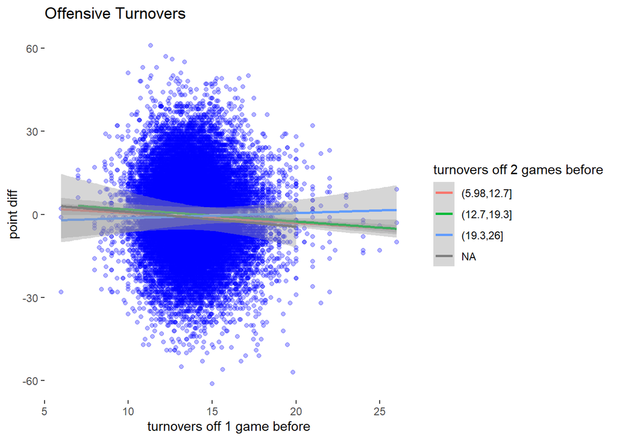

```r
# Create plot
g_1 <- ggplot(nba_model, # Set dataset
              aes(x = tov_1_off,
                  color = cut(tov_2_off,3), # Set y-axis
                  y = point_diff)) + # Set x-axis
  geom_point(color = "blue", alpha = 0.3) + # Use geom_point to get scatter plot
  geom_smooth(method = "lm") + # Add smoothing line
  theme_bw() + # Set theme for plot
  theme(panel.grid.major = element_blank(), # Turn of the background grid
        panel.grid.minor = element_blank(),
        panel.border = element_blank(),
        panel.background = element_blank()) +

  labs(x = "turnovers off 1 game before", # Set plot labels
       y = "point diff",
       title = "Offensive Turnovers",
       color = "turnovers off 2 games before")

g_1 # Generate plot
```

When there is a high number of offensive turnovers 2 games ago, the offensive turnovers from 1 game ago will have a mildly positive effect on point diff. When there are a mid-low number of offensive turnovers 2 games ago the offensive trunovers from 1 game ago have a mildly negative effect. The interaction between turnovers 1 game vs 2 games ago can change the relationship with the points diff.

- 5 - Fit a linear regression model with the two interaction terms included. (1 Point)

```r
fit2 <- lm(point_diff ~ . + tov_1_off * tov_2_off * ast_1_off * oreb_1_off, nba_model)

summary(fit2)
```

```
##
## Call:
## lm(formula = point_diff ~ . + tov_1_off * tov_2_off * ast_1_off *
##     oreb_1_off, data = nba_model)
##
## Residuals:
##     Min      1Q  Median      3Q     Max
## -57.353  -8.260  -0.002   8.292  56.769
##
## Coefficients: (16 not defined because of singularities)
##                                            Estimate Std. Error t value Pr(>|t|)
## (Intercept)                               1.402e+02  1.354e+02   1.036 0.300299
## fgm_1_off                                 1.368e+00  8.373e-01   1.634 0.102301
## fga_1_off                                -7.313e-01  3.926e-01  -1.863 0.062537
## fg3m_1_off                               -5.372e-01  4.666e-01  -1.151 0.249598
## fg3a_1_off                                4.288e-01  2.135e-01   2.009 0.044583
## fg2m_1_off                                       NA         NA      NA       NA
## fg2a_1_off                                       NA         NA      NA       NA
## ftm_1_off                                -4.262e-02  4.778e-01  -0.089 0.928936
## fta_1_off                                 3.955e-02  3.684e-01   0.107 0.914513
## oreb_1_off                               -1.405e+01  1.085e+01  -1.295 0.195332
## dreb_1_off                                2.191e-01  6.435e-02   3.404 0.000664
## treb_1_off                                       NA         NA      NA       NA
## ast_1_off                                -5.765e+00  5.307e+00  -1.086 0.277373
## stl_1_off                                 3.899e-01  9.308e-02   4.189 2.82e-05
## blk_1_off                                 1.884e-01  8.004e-02   2.354 0.018570
## tov_1_off                                -1.385e+01  7.902e+00  -1.753 0.079621
## pf_1_off                                  1.389e-01  6.599e-02   2.105 0.035328
## pts_1_off                                        NA         NA      NA       NA
## pctfg_1_off                              -5.775e+01  6.564e+01  -0.880 0.378965
## pctfg2_1_off                             -1.830e+01  2.282e+01  -0.802 0.422595
## pctfg3_1_off                              5.405e+00  7.307e+00   0.740 0.459502
## pctft_1_off                               9.555e+00  1.139e+01   0.839 0.401426
## fgm_1_def                                -2.769e+00  9.932e-01  -2.788 0.005303
## fga_1_def                                 1.295e+00  4.663e-01   2.778 0.005480
## fg3m_1_def                                8.497e-01  6.735e-01   1.262 0.207066
## fg3a_1_def                               -4.579e-01  3.055e-01  -1.499 0.133918
## fg2m_1_def                                       NA         NA      NA       NA
## fg2a_1_def                                       NA         NA      NA       NA
## ftm_1_def                                -5.953e-01  6.760e-01  -0.881 0.378535
```

[output cut: 160 more lines]

```
## oreb_1_off:tov_1_off                     .
## oreb_1_off:tov_2_off
## oreb_1_off:ast_1_off
## ast_1_off:tov_1_off:tov_2_off
## oreb_1_off:tov_1_off:tov_2_off
## oreb_1_off:ast_1_off:tov_1_off
## oreb_1_off:ast_1_off:tov_2_off
## oreb_1_off:ast_1_off:tov_1_off:tov_2_off
## ---
## Signif. codes:  0 '***' 0.001 '**' 0.01 '*' 0.05 '.' 0.1 ' ' 1
##
## Residual standard error: 12.77 on 27884 degrees of freedom
##   (430 observations deleted due to missingness)
## Multiple R-squared:  0.1575, Adjusted R-squared:  0.1551
## F-statistic: 64.36 on 81 and 27884 DF,  p-value: < 2.2e-16
```

```r
p_values <- summary(fit2)$coefficients[, "Pr(>|t|)"]
significant_terms2 <- summary(fit2)$coefficients[p_values < 0.001, ]
significant_terms2
```

```
##               Estimate  Std. Error    t value     Pr(>|t|)
## dreb_1_off  0.21905594 0.064347564   3.404262 6.643657e-04
## stl_1_off   0.38988370 0.093082600   4.188578 2.815705e-05
## ast_1_def  -0.23714620 0.064849933  -3.656846 2.558074e-04
## ast_2_def   0.22546965 0.064960510   3.470872 5.195550e-04
## elo_2      -0.02403177 0.001718297 -13.985808 2.686842e-44
## elo_1       0.02607334 0.001654713  15.757018 1.069462e-55
```

- 6 - How has the inclusion of the interaction terms affected the coefficients in the model? How has the inclusion of interaction terms affected the model fit? (1 Point)

2 Points for code quality and analysis decisions.